# ABRicate: reduce coverage intervals

Stephen Turner[^1]

2018-07-27

# ABRicate data

Read in the data and take a look.

```r
library(tidyverse)
ab <- read_tsv("abricate-results.tsv")
ab
```

```
## # A tibble: 196 x 12
##    `#FILE` SEQUENCE START   END GENE  COVERAGE COVERAGE_MAP GAPS
##    <chr>   <chr>    <int> <int> <chr> <chr>    <chr>        <chr>
##  1 /data/… k119_10…  5352  5530 vat(… 346-524… .......=/==… 2-Feb
##  2 /data/… k119_11…   600   728 car(… 562-690… ....==../..… 4-Feb
##  3 /data/… k119_12… 56449 57945 lsa(… 1-1497/… ===========… 0/0
##  4 /data/… k119_12… 13306 13950 blaO… 123-767… ..======/==… 2-Feb
##  5 /data/… k119_17…     3   487 blaO… 283-767… ....====/==… 2-Feb
##  6 /data/… k119_19…   252   395 blaO… 655-798… ......../..… 2-Feb
##  7 /data/… k119_27…  2082  2203 aph(… 454-575… ........===… 0/0
##  8 /data/… k119_34…  5462  6064 vat(… 1-603/6… ========/==… 4-Feb
##  9 /data/… k119_39… 13273 13381 oqxB… 1168-12… .....==....… 0/0
## 10 /data/… k119_87…   223   391 msr(… 1296-14… ...........… 0/0
## # ... with 186 more rows, and 4 more variables: `%COVERAGE` <dbl>,
## #   `%IDENTITY` <dbl>, DATABASE <chr>, ACCESSION <chr>
```

- Clean the names
- Remove excess stuff from the filename
- Separate coverage into range and length by the `/`
- Separate the new range into start and end by the `-`
- Make those three new variables integers.

```r
ab2 <- ab %>%
  janitor::clean_names() %>%
  select(file=number_file, gene, accession, coverage) %>%
  mutate(file=file %>% str_remove("/data/SRR606249_") %>% str_remove_all("1\\.|\\.fq\\.gz|_output.*")) %>%
  separate(coverage, into=c("range", "length"), sep="/") %>%
  separate(range, into=c("start", "end"), sep="-", remove=FALSE) %>%
  mutate_at(vars(start, end, length), as.integer)
ab2
```

```
## # A tibble: 196 x 7
##    file          gene         accession range     start   end length
##    <chr>         <chr>        <chr>     <chr>     <int> <int>  <int>
##  1 trim2_megahit vat(A)_1     L07778    346-524     346   524    660
##  2 trim2_megahit car(A)_1     M80346    562-690     562   690   1656
##  3 trim2_megahit lsa(A)_2     AY58982   1-1497        1  1497   1497
##  4 trim2_megahit blaOXA-181_1 HM992946  123-767     123   767    798
##  5 trim2_megahit blaOXA-181_1 HM992946  283-767     283   767    798
##  6 trim2_megahit blaOXA-48_2  AY236073  655-798     655   798    798
##  7 trim2_megahit aph(6)-Ic_1  X01702    454-575     454   575    801
##  8 trim2_megahit vat(B)_1     U19459    1-603         1   603    639
##  9 trim2_megahit oqxB_1       EU370913  1168-1276  1168  1276   3153
## 10 trim2_megahit msr(D)_2     AF274302  1296-1464  1296  1464   1464
## # ... with 186 more rows
```

Function to parse filename:

```r
parsefilename <- . %>%
  mutate(dataset=str_extract(file, "subset\\d+") %>% if_else(is.na(.), "full", .)) %>%
  mutate(trim=str_extract(file, "trim\\d+")) %>%
  mutate(assembler=str_extract(file, "spades|megahit")) %>%
  select(file, dataset, trim, assembler, everything())
```

See what it looks like to make sure it works:

```r
ab2 %>% distinct(file) %>% parsefilename
```

```
## # A tibble: 16 x 4
##    file                    dataset  trim   assembler
##    <chr>                   <chr>    <chr>  <chr>
##  1 trim2_megahit           full     trim2  megahit
##  2 trim2_spades            full     trim2  spades
##  3 trim30_megahit          full     trim30 megahit
##  4 trim30_spades           full     trim30 spades
##  5 subset10_trim2_megahit  subset10 trim2  megahit
##  6 subset10_trim2_spades   subset10 trim2  spades
##  7 subset10_trim30_megahit subset10 trim30 megahit
##  8 subset10_trim30_spades  subset10 trim30 spades
##  9 subset25_trim2_megahit  subset25 trim2  megahit
## 10 subset25_trim2_spades   subset25 trim2  spades
## 11 subset25_trim30_megahit subset25 trim30 megahit
## 12 subset25_trim30_spades  subset25 trim30 spades
## 13 subset50_trim2_megahit  subset50 trim2  megahit
## 14 subset50_trim2_spades   subset50 trim2  spades
## 15 subset50_trim30_megahit subset50 trim30 megahit
## 16 subset50_trim30_spades  subset50 trim30 spades
```

On all the data:

```r
ab2 %>% parsefilename
```

```
## # A tibble: 196 x 10
##    file   dataset trim  assembler gene  accession range start   end length
##    <chr>  <chr>   <chr> <chr>     <chr> <chr>     <chr> <int> <int>  <int>
##  1 trim2… full    trim2 megahit   vat(… L07778    346-…   346   524    660
##  2 trim2… full    trim2 megahit   car(… M80346    562-…   562   690   1656
##  3 trim2… full    trim2 megahit   lsa(… AY58982   1-14…     1  1497   1497
##  4 trim2… full    trim2 megahit   blaO… HM992946  123-…   123   767    798
##  5 trim2… full    trim2 megahit   blaO… HM992946  283-…   283   767    798
##  6 trim2… full    trim2 megahit   blaO… AY236073  655-…   655   798    798
##  7 trim2… full    trim2 megahit   aph(… X01702    454-…   454   575    801
##  8 trim2… full    trim2 megahit   vat(… U19459    1-603     1   603    639
##  9 trim2… full    trim2 megahit   oqxB… EU370913  1168…  1168  1276   3153
## 10 trim2… full    trim2 megahit   msr(… AF274302  1296…  1296  1464   1464
## # ... with 186 more rows
```

# Calculating coverage

## Toy problem

Now, the problem of coverage. Let’s look at a simple toy example of two genes *a* (length 20) and *b* (length 15) with coverages along particular intervals.

```r
toy <- tibble::tribble(
  ~start, ~end, ~length, ~gene,
  1, 5, 20, "a",
  11, 15, 20, "a",
  1, 4, 15, "b",
  2, 6, 15, "b",
  9, 10, 15, "b"
)
toy
```

```
## # A tibble: 5 x 4
##   start   end length gene
##   <dbl> <dbl>  <dbl> <chr>
## 1     1     5     20 a
## 2    11    15     20 a
## 3     1     4     15 b
## 4     2     6     15 b
## 5     9    10     15 b
```

Clearly *a* has coverage 10 and b has coverage 8.

My first thought to tackle this problem is to group by gene and sum the differences between start and end.

```r
toy %>%
  group_by(gene) %>%
  summarize(coverage=sum(end-start+1))
```

```
## # A tibble: 2 x 2
##   gene  coverage
##   <chr>    <dbl>
## 1 a           10
## 2 b           11
```

But this clearly illustrates the problem - it works fine in *a* but the intervals in *b* need to be reduced because the first two intervals overlap.

Use the [plyranges package](https://bioconductor.org/packages/release/bioc/html/plyranges.html) to treat these as ranges so you can reduce them.

```r
library(plyranges)
```

First, see what this looks like as ranges.

```r
toy %>%
  as_iranges()
```

```
## IRanges object with 5 ranges and 2 metadata columns:
##           start       end     width |    length        gene
##       <integer> <integer> <integer> | <numeric> <character>
##   [1]         1         5         5 |        20           a
##   [2]        11        15         5 |        20           a
##   [3]         1         4         4 |        15           b
##   [4]         2         6         5 |        15           b
##   [5]         9        10         2 |        15           b
```

Now, reduce those ranges, separately by each gene/length.

```r
toy %>%
  as_iranges() %>%
  group_by(gene, length) %>%
  reduce_ranges()
```

```
## IRanges object with 4 ranges and 2 metadata columns:
##           start       end     width |        gene    length
##       <integer> <integer> <integer> | <character> <numeric>
##   [1]         1         6         6 |           b        15
##   [2]         9        10         2 |           b        15
##   [3]         1         5         5 |           a        20
##   [4]        11        15         5 |           a        20
```

Turn it back into a regular data frame.

```r
toyreduced <- toy %>%
  as_iranges() %>%
  group_by(gene, length) %>%
  reduce_ranges() %>%
  DataFrame() %>%
  as.data.frame() %>%
  as_tibble() %>%
  set_names(~str_remove(., "X\\.")) %>%
  arrange(gene, start, end)
```

Compare this:

```r
toyreduced
```

```
## # A tibble: 4 x 5
##   start   end width gene  length
##   <int> <int> <int> <chr>  <dbl>
## 1     1     5     5 a         20
## 2    11    15     5 a         20
## 3     1     6     6 b         15
## 4     9    10     2 b         15
```

To our original:

```r
toy
```

```
## # A tibble: 5 x 4
##   start   end length gene
##   <dbl> <dbl>  <dbl> <chr>
## 1     1     5     20 a
## 2    11    15     20 a
## 3     1     4     15 b
## 4     2     6     15 b
## 5     9    10     15 b
```

Now we can easily get coverage. While we’re at it, go ahead and add columns detailing the total number of ranges, and what those are, as a sanity check.

```r
toyreduced %>%
  mutate(ranges=paste(start, end, sep="-")) %>%
  group_by(gene, length) %>%
  summarize(ranges=paste(ranges, collapse=";"),
            nranges=dplyr::n(),
            coverage=sum(width)) %>%
  mutate(pct_coverage=coverage/length)
```

```
## # A tibble: 2 x 6
## # Groups:   gene [2]
##   gene  length ranges    nranges coverage pct_coverage
##   <chr>  <dbl> <chr>       <int>    <int>        <dbl>
## 1 a         20 1-5;11-15       2       10        0.5
## 2 b         15 1-6;9-10        2        8        0.533
```

## On the ABRicate data

Let’s do this on our data.

```r
abreduced <- ab2 %>%
  as_iranges() %>%
  group_by(file, gene, accession, length) %>%
  reduce_ranges() %>%
  DataFrame() %>%
  as.data.frame() %>%
  as_tibble() %>%
  set_names(~str_remove(., "X\\.")) %>%
  distinct() %>%
  mutate(ranges=paste(start, end, sep="-")) %>%
  group_by(file, gene, length) %>%
  summarize(ranges=paste(ranges, collapse=";"),
            nranges=dplyr::n(),
            coverage=sum(width)) %>%
  ungroup() %>%
  mutate(pct_coverage=coverage/length) %>%
  arrange(file, gene, desc(nranges), ranges)
```

Parse the filename using the function above.

```r
abreduced <- abreduced %>% parsefilename()
abreduced
```

```
## # A tibble: 145 x 10
##    file  dataset trim  assembler gene  length ranges nranges coverage
##    <chr> <chr>   <chr> <chr>     <chr>  <int> <chr>    <int>    <int>
##  1 subs… subset… trim2 megahit   catB…    639 12-433       1      422
##  2 subs… subset… trim2 megahit   cepA…    903 686-8…       1      208
##  3 subs… subset… trim2 megahit   lsa(…   1497 1-343…       3      789
##  4 subs… subset… trim2 megahit   oqxB…   3153 987-1…       2      683
##  5 subs… subset… trim2 megahit   vat(…    660 346-5…       1      179
##  6 subs… subset… trim2 spades    blaO…    798 458-7…       1      341
##  7 subs… subset… trim2 spades    car(…   1656 562-6…       1      129
##  8 subs… subset… trim2 spades    catB…    639 12-433       1      422
##  9 subs… subset… trim2 spades    cepA…    903 640-8…       1      254
## 10 subs… subset… trim2 spades    lsa(…   1497 1-671…       3     1200
## # ... with 135 more rows, and 1 more variable: pct_coverage <dbl>
```

Now:

1. Group by dataset, gene, and trim, and add a column showing which assembler(s) detected this entry.
2. Group by dataset, gene, and assembler, and add a column showing which trim length was detected this entry.
3. Add a final column that concatenates these two. This will be used for coloring.

```r
abreduced <- abreduced %>%
  group_by(dataset, gene, trim) %>%
  mutate(assemblers_detected=paste(assembler, collapse="+")) %>%
  ungroup() %>%
  group_by(dataset, gene, assembler) %>%
  mutate(trim_detected=paste(trim, collapse="+")) %>%
  ungroup() %>%
  mutate(detected=paste(assemblers_detected, trim_detected, sep=";"))
```

Print the table nicely:

```r
knitr::kable(abreduced)
```

| file | dataset | trim | assembler | gene | length | ranges | nranges | coverage | pct_coverage | assemblers_detected | trim_detected | detected |
| --- | --- | --- | --- | --- | --- | --- | --- | --- | --- | --- | --- | --- |
| subset10_trim2_megahit | subset10 | trim2 | megahit | catB7_1 | 639 | 12-433 | 1 | 422 | 0.6604069 | megahit+spades | trim2+trim30 | megahit+spades;trim2+trim30 |
| subset10_trim2_megahit | subset10 | trim2 | megahit | cepA_1 | 903 | 686-893 | 1 | 208 | 0.2303433 | megahit+spades | trim2+trim30 | megahit+spades;trim2+trim30 |
| subset10_trim2_megahit | subset10 | trim2 | megahit | lsa(A)_2 | 1497 | 1-343;827-1159;1385-1497 | 3 | 789 | 0.5270541 | megahit+spades | trim2+trim30 | megahit+spades;trim2+trim30 |
| subset10_trim2_megahit | subset10 | trim2 | megahit | oqxB_1 | 3153 | 987-1368;2660-2960 | 2 | 683 | 0.2166191 | megahit+spades | trim2+trim30 | megahit+spades;trim2+trim30 |
| subset10_trim2_megahit | subset10 | trim2 | megahit | vat(A)_1 | 660 | 346-524 | 1 | 179 | 0.2712121 | megahit+spades | trim2+trim30 | megahit+spades;trim2+trim30 |
| subset10_trim2_spades | subset10 | trim2 | spades | blaOXA-54_1 | 798 | 458-798 | 1 | 341 | 0.4273183 | spades | trim2+trim30 | spades;trim2+trim30 |
| subset10_trim2_spades | subset10 | trim2 | spades | car(A)_1 | 1656 | 562-690 | 1 | 129 | 0.0778986 | spades | trim2 | spades;trim2 |
| subset10_trim2_spades | subset10 | trim2 | spades | catB7_1 | 639 | 12-433 | 1 | 422 | 0.6604069 | megahit+spades | trim2+trim30 | megahit+spades;trim2+trim30 |
| subset10_trim2_spades | subset10 | trim2 | spades | cepA_1 | 903 | 640-893 | 1 | 254 | 0.2812846 | megahit+spades | trim2+trim30 | megahit+spades;trim2+trim30 |
| subset10_trim2_spades | subset10 | trim2 | spades | lsa(A)_2 | 1497 | 1-671;816-1225;1379-1497 | 3 | 1200 | 0.8016032 | megahit+spades | trim2+trim30 | megahit+spades;trim2+trim30 |
| subset10_trim2_spades | subset10 | trim2 | spades | oqxB_1 | 3153 | 987-1276;1385-1500;2659-2885 | 3 | 633 | 0.2007612 | megahit+spades | trim2+trim30 | megahit+spades;trim2+trim30 |
| subset10_trim2_spades | subset10 | trim2 | spades | vat(A)_1 | 660 | 346-524 | 1 | 179 | 0.2712121 | megahit+spades | trim2+trim30 | megahit+spades;trim2+trim30 |
| subset10_trim2_spades | subset10 | trim2 | spades | vat(B)_1 | 639 | 1-530 | 1 | 530 | 0.8294210 | spades | trim2+trim30 | spades;trim2+trim30 |
| subset10_trim30_megahit | subset10 | trim30 | megahit | catB7_1 | 639 | 12-433 | 1 | 422 | 0.6604069 | megahit+spades | trim2+trim30 | megahit+spades;trim2+trim30 |
| subset10_trim30_megahit | subset10 | trim30 | megahit | cepA_1 | 903 | 686-893 | 1 | 208 | 0.2303433 | megahit+spades | trim2+trim30 | megahit+spades;trim2+trim30 |
| subset10_trim30_megahit | subset10 | trim30 | megahit | lsa(A)_2 | 1497 | 1-343;828-1159;1379-1497 | 3 | 794 | 0.5303941 | megahit+spades | trim2+trim30 | megahit+spades;trim2+trim30 |
| subset10_trim30_megahit | subset10 | trim30 | megahit | oqxB_1 | 3153 | 987-1368 | 1 | 382 | 0.1211545 | megahit+spades | trim2+trim30 | megahit+spades;trim2+trim30 |
| subset10_trim30_megahit | subset10 | trim30 | megahit | vat(A)_1 | 660 | 346-524 | 1 | 179 | 0.2712121 | megahit+spades | trim2+trim30 | megahit+spades;trim2+trim30 |
| subset10_trim30_spades | subset10 | trim30 | spades | blaOXA-54_1 | 798 | 458-725 | 1 | 268 | 0.3358396 | spades | trim2+trim30 | spades;trim2+trim30 |
| subset10_trim30_spades | subset10 | trim30 | spades | catB7_1 | 639 | 12-433 | 1 | 422 | 0.6604069 | megahit+spades | trim2+trim30 | megahit+spades;trim2+trim30 |
| subset10_trim30_spades | subset10 | trim30 | spades | cepA_1 | 903 | 640-893 | 1 | 254 | 0.2812846 | megahit+spades | trim2+trim30 | megahit+spades;trim2+trim30 |
| subset10_trim30_spades | subset10 | trim30 | spades | lsa(A)_2 | 1497 | 1-376;394-671;816-1225;1379-1497 | 4 | 1183 | 0.7902472 | megahit+spades | trim2+trim30 | megahit+spades;trim2+trim30 |
| subset10_trim30_spades | subset10 | trim30 | spades | oqxB_1 | 3153 | 1168-1276;1385-1500;2659-2960 | 3 | 527 | 0.1671424 | megahit+spades | trim2+trim30 | megahit+spades;trim2+trim30 |
| subset10_trim30_spades | subset10 | trim30 | spades | vat(A)_1 | 660 | 346-524 | 1 | 179 | 0.2712121 | megahit+spades | trim2+trim30 | megahit+spades;trim2+trim30 |
| subset10_trim30_spades | subset10 | trim30 | spades | vat(B)_1 | 639 | 1-530 | 1 | 530 | 0.8294210 | spades | trim2+trim30 | spades;trim2+trim30 |
| subset25_trim2_megahit | subset25 | trim2 | megahit | blaOXA-181_1 | 798 | 298-798 | 1 | 501 | 0.6278195 | megahit+spades | trim2+trim30 | megahit+spades;trim2+trim30 |
| subset25_trim2_megahit | subset25 | trim2 | megahit | blaOXA-48_2 | 798 | 123-251 | 1 | 129 | 0.1616541 | megahit | trim2+trim30 | megahit;trim2+trim30 |
| subset25_trim2_megahit | subset25 | trim2 | megahit | car(A)_1 | 1656 | 562-690;1093-1224 | 2 | 261 | 0.1576087 | megahit+spades | trim2+trim30 | megahit+spades;trim2+trim30 |
| subset25_trim2_megahit | subset25 | trim2 | megahit | cepA_1 | 903 | 665-893 | 1 | 229 | 0.2535991 | megahit | trim2+trim30 | megahit;trim2+trim30 |
| subset25_trim2_megahit | subset25 | trim2 | megahit | lsa(A)_2 | 1497 | 1-1497 | 1 | 1497 | 1.0000000 | megahit+spades | trim2+trim30 | megahit+spades;trim2+trim30 |

[output cut: 115 more lines]

Write it to file if you wish.

```r
write_csv(abreduced, path="abricate-results-parse-reduced-coverage.csv")
```

## Visualize

Percent coverage by sample, faceted by gene.

```r
p <- ggplot(abreduced, aes(file, pct_coverage)) +
  geom_col() +
  facet_wrap(~gene) +
  theme_classic() +
  theme(axis.text.x=element_text(angle=90)) + #theme(axis.text.x=element_blank()) +
  geom_hline(yintercept=.9, col="red2", lty=3)
```

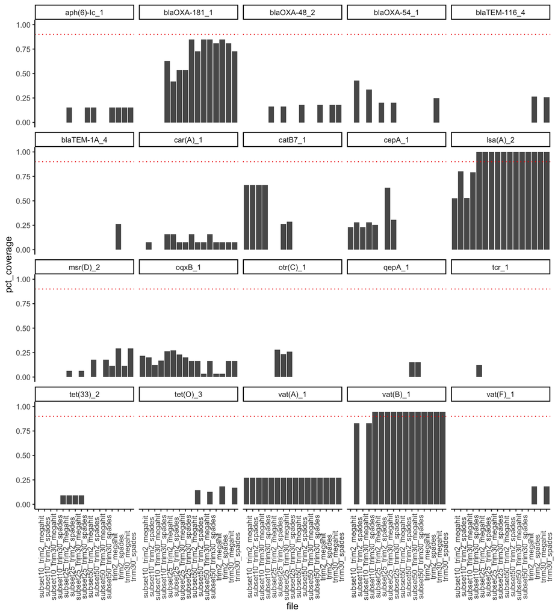

```r
p
```

Color code by assembler detected:

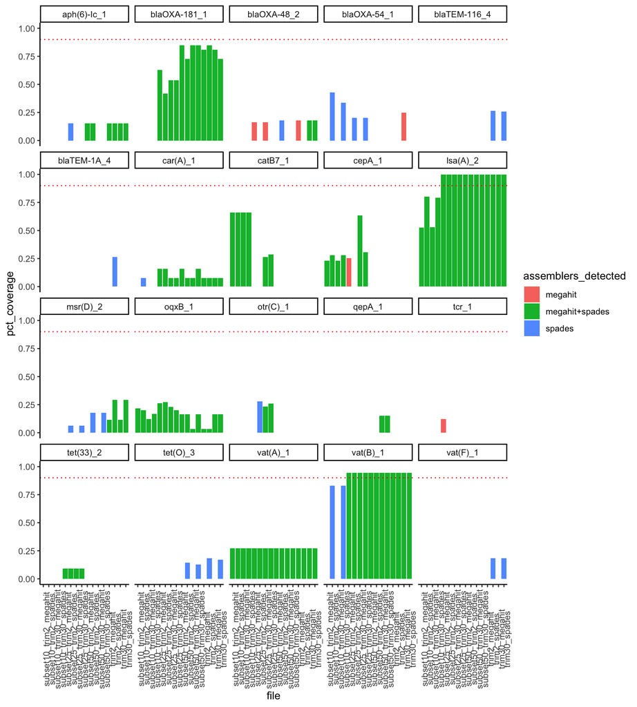

```r
p + aes(fill=assemblers_detected)
```

Color code by trim length detected:

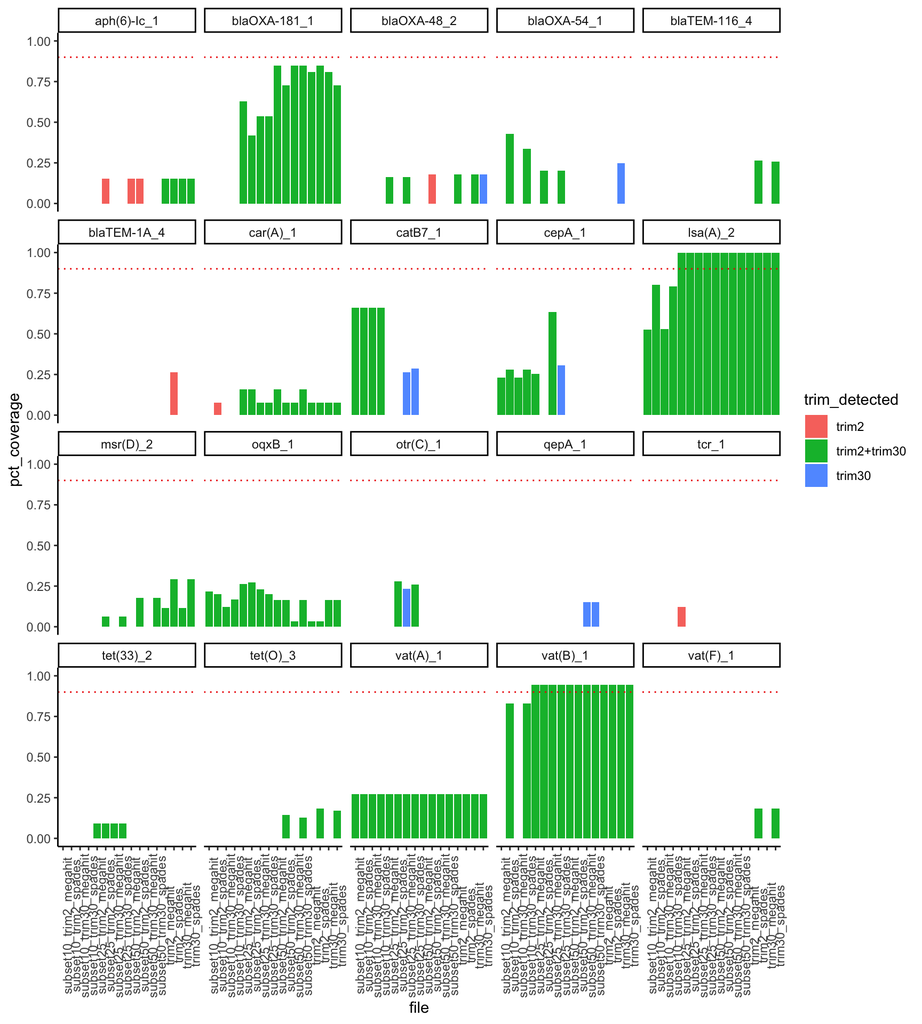

```r
p + aes(fill=trim_detected)
```

Color code by assembler+trim length detected combination:

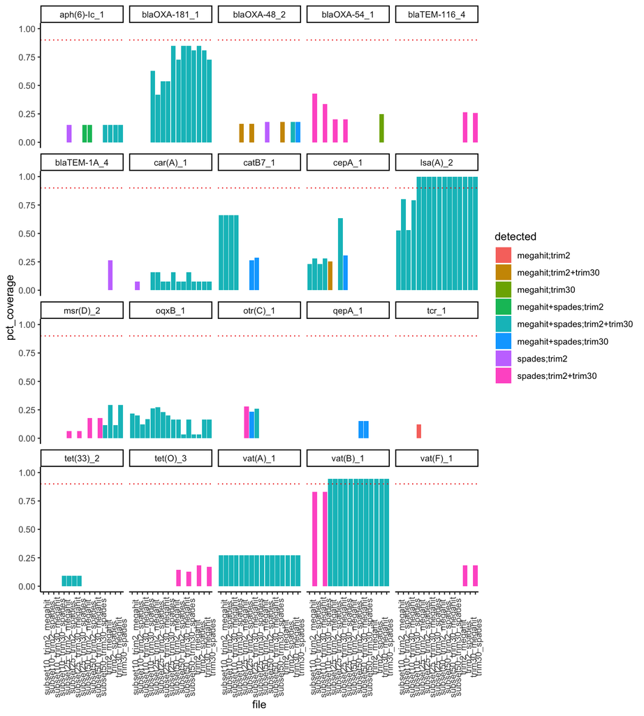

```r
p + aes(fill=detected)
```

[^1]: sdt5z@virginia.edu